# SES Analytic Dataset - Data Guide

Nebraska 2025 Study

Author

Kidsights Data Platform

Published

April 21, 2026

# Overview

## Dataset Description

This data guide provides comprehensive documentation for the **SES Analytic Dataset** created from the Nebraska 2025 (NE25) study. The dataset was designed to support research questions related to socioeconomic status, material hardship, home learning environment, and child development outcomes.

**Dataset Files:** - `ses_analytic_dataset.csv` - CSV format - `ses_analytic_dataset.rds` - R format - `ses_analytic_dataset.sav` - SPSS format - `ses_analytic_codebook.csv` - Variable metadata

**Created:** 2026-04-21

## Dataset Characteristics

Dataset Overview

| Characteristic | Value |
| --- | --- |
| Total Variables | 124 |
| Total Participants | 2645 |
| Eligible Participants | 2645 |
| Age Range | 0.0 - 6.0 years |
| Data Collection Period | 2024-2025 |

## Variable Organization

# Sample Composition

## Inclusion Criteria

Sample Inclusion Summary

| Criterion | N | Percentage |
| --- | --- | --- |
| Total Records | 2645 | 100.0% |
| Meets Inclusion | 2645 | 100.0% |
| Eligible | 2645 | 100.0% |
| Not Influential | 2645 | 100.0% |
| Excluded | 0 | 0.0% |

**Inclusion Definition:** `meets_inclusion = TRUE` requires: - `eligible = TRUE` (meets study criteria) - `influential = FALSE` (not flagged as high-leverage observation)

## Age Distribution

Age Distribution of Included Participants

| Age (years) | N | Percentage | Mean Age (years) | SD |
| --- | --- | --- | --- | --- |
| 0 | 267 | 10.1% | 0.68 | 0.25 |
| 1 | 422 | 16.0% | 1.55 | 0.29 |
| 2 | 521 | 19.7% | 2.48 | 0.30 |
| 3 | 468 | 17.7% | 3.53 | 0.28 |
| 4 | 446 | 16.9% | 4.48 | 0.29 |
| 5 | 521 | 19.7% | 5.53 | 0.28 |

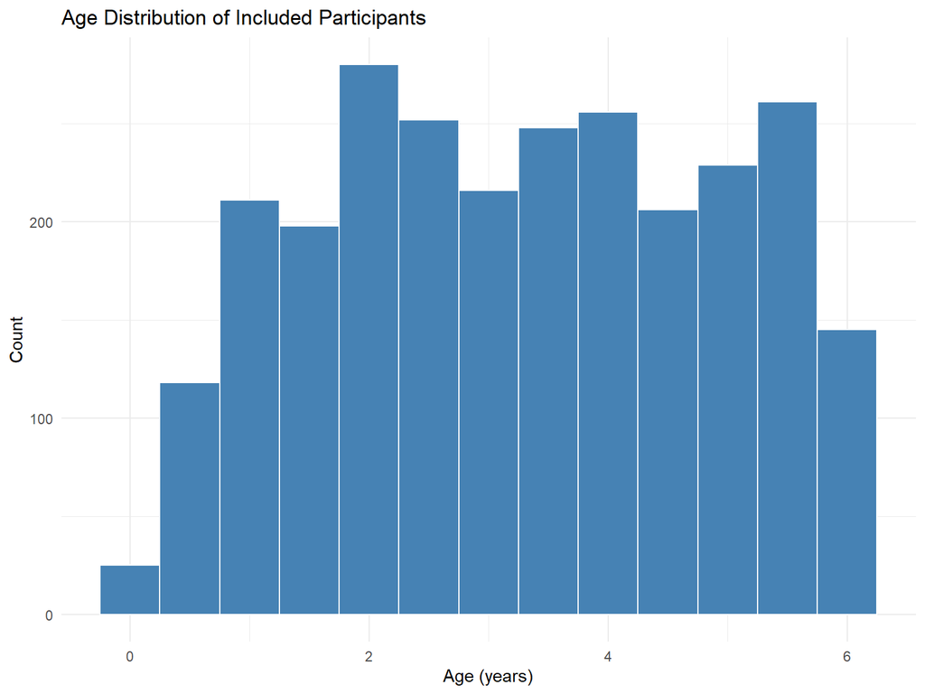

Age Distribution Histogram

## Demographics Summary

### Sex

Sex Distribution

| Sex | N | Percentage |
| --- | --- | --- |
| Male | 1324 | 50.1% |
| Female | 1285 | 48.6% |
| Missing | 36 | 1.4% |

### Race/Ethnicity

Race/Ethnicity Distribution

| Race/Ethnicity | N | Percentage |
| --- | --- | --- |
| White, non-Hisp. | 1575 | 59.5% |
| Hispanic | 508 | 19.2% |
| Black or African American, non-Hisp. | 208 | 7.9% |
| Two or More, non-Hisp. | 179 | 6.8% |
| NA | 72 | 2.7% |
| Asian or Pacific Islander, non-Hisp. | 71 | 2.7% |
| American Indian or Alaska Native, non-Hisp. | 16 | 0.6% |
| Some Other Race, non-Hisp. | 16 | 0.6% |

### Maternal Education

Maternal Education Distribution

| Maternal Education | N | Percentage |
| --- | --- | --- |
| NA | 714 | 27.0% |
| Master's Degree (MA, MS, MSW, MBA) | 713 | 27.0% |
| Doctorate (PhD, EdD) or Professional Degree (MD, DDS, DVM, JD) | 440 | 16.6% |
| Associate Degree (AA, AS) | 262 | 9.9% |
| Completed a vocational, trade, or business school program | 249 | 9.4% |
| Bachelor's Degree (BA, BS, AB) | 169 | 6.4% |
| Some College Credit, but No Degree | 47 | 1.8% |
| High School Graduate or GED Completed | 42 | 1.6% |
| 9th-12th grade, No diploma | 9 | 0.3% |

# Variable Profiles by Domain

## 1. Geography & Neighborhood (9 variables)

### Geography

Geography Variables

| Variable | Label | Type | Missing % |
| --- | --- | --- | --- |
| county | County FIPS code(s) - semicolon-separated if ZIP spans multiple counties | character | 0 |
| county_name | County name(s) - semicolon-separated if ZIP spans multiple counties | character | 0 |
| puma | Public Use Microdata Area(s) - semicolon-separated if ZIP spans multiple PUMAs (2020 Census) | character | 0 |
| urban_rural | Urban/Rural classification(s) (U=Urban, R=Rural) - semicolon-separated if ZIP is mixed (2022 Census) | factor | 0 |
| urban_pct | Percentage of ZIP population in urban areas (0-100) | numeric | 0 |

#### Urban/Rural Distribution

Urban/Rural Classification

| Urban/Rural | N | Percentage |
| --- | --- | --- |
| R | 639 | 24.2% |
| R; U | 30 | 1.1% |
| U | 773 | 29.2% |
| U; R | 1203 | 45.5% |

### Neighborhood/Community

Neighborhood/Community Variables

| Variable | Label | Missing % |
| --- | --- | --- |
| cqfb009_neighborhood_help | People in this neighborhood help each other out. | 1.06 |
| cqfb010_neighborhood_watch | We watch out for each other's children in this neighborhood. | 1.44 |
| cqfb011_neighborhood_safe | This child is safe in our neighborhood. | 0.98 |
| cqfb012_community_support | When we encounter difficulties, we know where to go for help in our community. | 1.29 |

## 2. Socioeconomic Status (4 variables)

SES Variables - Descriptive Statistics

| Statistic | Value |
| --- | --- |
| Income: Mean | $118669 |
| Income: SD | $89158 |
| Income: Missing N | 4 |
| FPL: Mean | 374% |
| FPL: SD | 298% |
| FPL: Missing N | 107 |
| Family Size: Mean | 9.3 |
| Family Size: SD | 70.9 |
| Family Size: Missing N | 95 |

### Federal Poverty Level Categories

Federal Poverty Level Distribution

| FPL Category | N | Percentage |
| --- | --- | --- |
| 400+% FPL | 906 | 34.3% |
| 300-399% FPL | 450 | 17.0% |
| 100-199% FPL | 414 | 15.7% |
| 200-299% FPL | 414 | 15.7% |
| <100% FPL | 354 | 13.4% |
| NA | 107 | 4.0% |

## 3. Government Services (7 variables)

**Question:** “Is your family enrolled in any of the following programs or services?”

Government Services Enrollment

| Service | Variable | Enrolled | Not Enrolled | Missing | Enrollment % |
| --- | --- | --- | --- | --- | --- |
| Medicaid | cqr007_medicaid | 857 | 1788 | 0 | 32.4% |
| Child care subsidies (Title XX) | cqr007_childcare_subsidy | 176 | 2469 | 0 | 6.7% |
| Cash assistance (welfare) | cqr007_cash_assistance | 76 | 2569 | 0 | 2.9% |
| Free/reduced-cost school meals | cqr007_free_reduced_meals | 406 | 2239 | 0 | 15.3% |
| Food Stamps/SNAP | cqr007_snap | 389 | 2256 | 0 | 14.7% |
| Early Head Start/Head Start | cqr007_head_start | 208 | 2437 | 0 | 7.9% |
| WIC Program | cqr007_wic | 521 | 2124 | 0 | 19.7% |

## 4. Material Hardship & Food Security (10 variables)

### Material Hardship

**Question:** “Since your child was born, how often has it been very hard to cover the basics, like food and housing, on your family’s income?”

Hardship Covering Basics

| Response | N | Percentage |
| --- | --- | --- |
| 0 | 1141 | 43.1% |
| 1 | 918 | 34.7% |
| 2 | 479 | 18.1% |
| 3 | 93 | 3.5% |
| NA | 14 | 0.5% |

### Food Insecurity Scale (FIES)

Food Insecurity Scale Items

| Item | Variable | Missing % |
| --- | --- | --- |
| Ability to afford food needed | cqfa006_food_afford | 0.57 |
| Worried would not have enough food | mmifs009_food_worry | 63.63 |
| Unable to eat healthy/nutritious food | mmifs010_food_unhealthy | 63.82 |
| Ate only a few kinds of food | mmifs011_food_limited_variety | 63.78 |
| Had to skip a meal | mmifs012_food_skip_meal | 63.78 |
| Ate less than should | mmifs013_food_ate_less | 63.82 |
| Household ran out of food | mmifs014_food_ran_out | 63.82 |
| Hungry but did not eat | mmifs015_food_hungry | 63.82 |
| Went without eating for whole day | mmifs016_food_whole_day_without | 63.93 |

## 5. Caregiver Mental Health & ACEs (10 variables)

### Depression Screening (PHQ-2)

**Items:** “Over the last 2 weeks, how often have you been bothered by…”

```
**PHQ-2 Total Score Range:** 0-6
```

```
**Clinical Cutoff:** ≥3 indicates likely depression
```

PHQ-2 Depression Screening

| Statistic | Value |
| --- | --- |
| Mean | 0.84 |
| SD | 1.31 |
| Range | 0 - 6 |
| Positive Screen N | 282 |
| Positive Screen % | 10.8% |
| Missing N | 30 |

### Anxiety Screening (GAD-2)

**Items:** “Over the last 2 weeks, how often have you been bothered by…”

```
**GAD-2 Total Score Range:** 0-6
```

```
**Clinical Cutoff:** ≥3 indicates likely anxiety
```

GAD-2 Anxiety Screening

| Statistic | Value |
| --- | --- |
| Mean | 1.20 |
| SD | 1.45 |
| Range | 0 - 6 |
| Positive Screen N | 376 |
| Positive Screen % | 14.4% |
| Missing N | 32 |

### Caregiver ACEs (Childhood)

Caregiver Childhood ACE Scores

| Statistic | Value |
| --- | --- |
| Mean ACE Score | 1.99 |
| SD | 2.50 |
| Range | 0 - 10 |
| Missing N | 329 |

Caregiver ACE Risk Categories

| ACE Risk Category | N | Percentage |
| --- | --- | --- |
| No ACEs | 968 | 36.6% |
| 4+ ACEs | 532 | 20.1% |
| 2-3 ACEs | 432 | 16.3% |
| 1 ACE | 384 | 14.5% |
| NA | 329 | 12.4% |

The Family Care Indicators (FCI) scale measures the home learning environment across 4 sections:

### Section A: Reading Materials in Home (3 variables)

FCI Section A: Reading Materials

| Item | Variable | Missing % |
| --- | --- | --- |
| Adult books in home | fci_a_1_books_home | 0.42 |
| Magazines/newspapers in household | fci_a_2_magazines_newspapers | 1.13 |
| Times per week child sees adults reading | fci_a_3_see_adults_reading | 0.83 |

### Section B: Children’s Books (2 variables)

FCI Section B: Children's Books

| Item | Variable | Missing % |
| --- | --- | --- |
| Has children's books or picture books | fci_b_1_has_childrens_books | 1.40 |
| Number of children's books at home | fci_b_2_num_childrens_books | 4.65 |

### Section C: Play Materials/Toys (11 variables)

**Question:** “Does your child have…”

FCI Section C: Play Materials/Toys

| Item | Variable | Missing % |
| --- | --- | --- |
| Home-made toys | fci_c_1_toys_homemade | 2.12 |
| Store-bought/manufactured toys | fci_c_2_toys_store_bought | 1.17 |
| Household objects or outdoor objects | fci_c_3_toys_household_objects | 1.47 |
| Things that make or play music | fci_c_4_toys_music | 1.21 |
| Things for drawing or writing | fci_c_5_toys_drawing_writing | 1.59 |
| Picture books (not schoolbooks) | fci_c_6_toys_picture_books | 2.04 |
| Things for stacking/constructing/building | fci_c_7_toys_building | 2.38 |
| Things encouraging movement | fci_c_8_toys_movement | 1.63 |
| Toys for learning colors or shapes | fci_c_9_toys_learning | 1.85 |
| Things for pretending | fci_c_10_toys_pretend | 3.02 |
| Electronic devices (not radio/TV) | fci_c_11_electronic_devices | 1.44 |

### Section D: Caregiver-Child Activities (11 variables)

**Question:** “In the past week, did you or another family member…”

FCI Section D: Caregiver-Child Activities

| Item | Variable | Missing % |
| --- | --- | --- |
| Read books or look at picture books | fci_d_1_read_books | 1.59 |
| Tell stories | fci_d_2_tell_stories | 2.65 |
| Sing songs or say rhymes | fci_d_3_sing_songs | 2.57 |
| Take child outside home/yard | fci_d_4_go_outside | 1.66 |
| Play with child | fci_d_5_play_together | 2.04 |
| Count things with child | fci_d_6_count_things | 1.85 |
| Draw or paint things | fci_d_7_draw_paint | 1.93 |
| Construct things | fci_d_8_build_construct | 3.02 |
| Do household chores together | fci_d_9_chores_together | 2.27 |
| Do physical activities | fci_d_10_physical_activity | 1.59 |
| Child has place to keep toys/treasures | fci_d_11_toy_storage_space | 1.81 |

## 7. Child Characteristics (6 variables)

### Positive Characteristics

**Question:** “How often is this child…”

Child Positive Characteristics

| Item | Variable | Missing % |
| --- | --- | --- |
| Affectionate and tender | mmi110_child_affectionate | 3.29 |
| Bounces back quickly when things don't go their way | mmi111_child_resilient | 3.25 |
| Shows interest and curiosity in learning new things | mmi112_child_curious | 3.40 |
| Smiles and laughs | mmi113_child_happy | 3.18 |

### Child ACEs

Child ACE Scores

| Statistic | Value |
| --- | --- |
| Mean ACE Score | 0.42 |
| SD | 1.13 |
| Range | 0 - 8 |
| Missing N | 156 |

Child ACE Risk Categories

| ACE Risk Category | N | Percentage |
| --- | --- | --- |
| No ACEs | 1993 | 75.3% |
| 1 ACE | 278 | 10.5% |
| NA | 156 | 5.9% |
| 2-3 ACEs | 126 | 4.8% |
| 4+ ACEs | 92 | 3.5% |

# Child Development Outcomes (Age-Stratified)

This section presents child development outcomes **stratified by age** (floor of `years_old`).

**Important Notes:** - **D-scores are masked for children ≥42 months** (3.5 years) as D-scores are not calibrated for older ages - **CREDI scores** are designed for children 0-3 years - **HRTL classifications** are designed for children 3-5 years

## Overall Sample by Age

Sample Size by Age Group

| Age (years) | N | % of Sample |
| --- | --- | --- |
| 0 | 267 | 10.1% |
| 1 | 422 | 16.0% |
| 2 | 521 | 19.7% |
| 3 | 468 | 17.7% |
| 4 | 446 | 16.9% |
| 5 | 521 | 19.7% |

## Kidsights Person-Fit Scores (Ages 0-5)

Kidsights person-fit scores from the 2022 GSED scale calibration.

Overall Kidsights Score by Age

| Age | N | Mean | SD | Min | Max |
| --- | --- | --- | --- | --- | --- |
| 0 | 267 | -4.84 | 2.28 | -11.943 | 4.336 |
| 1 | 422 | -1.00 | 1.20 | -4.762 | 2.389 |
| 2 | 521 | 0.73 | 0.96 | -5.070 | 5.498 |
| 3 | 468 | 1.93 | 1.05 | -1.169 | 6.058 |
| 4 | 446 | 2.94 | 1.32 | -7.660 | 6.431 |
| 5 | 521 | 3.86 | 1.31 | -2.385 | 7.345 |

### Kidsights Domain Scores by Age

[output not shown]

[output cut: 328 more lines]

[output not shown]

## D-Scores (Ages 0-3.5 years)

**Note:** D-scores are masked (set to NA) for children ≥42 months (3.5 years).

D-Scores by Age

| Age | N | Mean D-score | SD | Min | Max | Mean Items (n) | Missing N |
| --- | --- | --- | --- | --- | --- | --- | --- |
| 0 | 267 | 43.15 | 10.11 | 12.25 | 77.84 | 28.5 | 0 |
| 1 | 422 | 62.02 | 6.68 | 42.70 | 80.32 | 28.1 | 0 |
| 2 | 517 | 70.60 | 4.88 | 44.28 | 81.01 | 14.9 | 4 |
| 3 | 212 | 74.16 | 3.43 | 67.79 | 79.29 | 2.0 | 256 |
| 4 | 0 | NaN | NA | Inf | -Inf | NaN | 446 |
| 5 | 0 | NaN | NA | Inf | -Inf | NaN | 521 |

## CREDI Scores (Ages 0-3 years)

Overall CREDI Score by Age (0-3 years)

| Age | N | Mean | SD |
| --- | --- | --- | --- |
| 0 | 227 | 44.61 | 3.13 |
| 1 | 391 | 49.48 | 2.69 |
| 2 | 266 | 51.71 | 2.52 |
| 3 | 0 | NaN | NA |

### CREDI Domain Scores by Age

[output not shown]

[output cut: 96 more lines]

[output not shown]

## HRTL Classifications (Ages 3-5 years)

Healthy & Ready to Learn (HRTL) school readiness classifications for children 3-5 years.

**Categories:** On-Track, Emerging, Needs Support

**Note:** Motor Development domain is masked due to high missingness (93%).

HRTL Sample by Age (3-5 years)

| Age | N |
| --- | --- |
| 3 | 468 |
| 4 | 446 |
| 5 | 521 |

[output not shown]

[output cut: 288 more lines]

[output not shown]

# Cross-Reference Tables

## Variable Renaming Map

This table shows the mapping from original database variable names to renamed analytic variable names (where applicable).

Variable Renaming Map (Selected Variables)

| Original Variable | Analytic Variable | Transformation |
| --- | --- | --- |
| general_gsed_pf_2022 | general_pf | Shortened suffix |
| feeding_gsed_pf_2022 | feeding_pf | Shortened suffix |
| externalizing_gsed_pf_2022 | externalizing_pf | Shortened suffix |
| internalizing_gsed_pf_2022 | internalizing_pf | Shortened suffix |
| sleeping_gsed_pf_2022 | sleeping_pf | Shortened suffix |
| social_competency_gsed_pf_2022 | social_competency_pf | Shortened suffix |
| cqfa005 | cqfa005_hardship_basics | Added descriptive suffix |
| cqfa006 | cqfa006_food_afford | Added descriptive suffix |
| mmifs009 | mmifs009_food_worry | Added descriptive suffix |
| mmifs010 | mmifs010_food_unhealthy | Added descriptive suffix |
| mmifs011 | mmifs011_food_limited_variety | Added descriptive suffix |
| mmifs012 | mmifs012_food_skip_meal | Added descriptive suffix |
| mmifs013 | mmifs013_food_ate_less | Added descriptive suffix |
| mmifs014 | mmifs014_food_ran_out | Added descriptive suffix |
| mmifs015 | mmifs015_food_hungry | Added descriptive suffix |
| mmifs016 | mmifs016_food_whole_day_without | Added descriptive suffix |
| cqr007___1 | cqr007_medicaid | Descriptive suffix |
| cqr007___2 | cqr007_childcare_subsidy | Descriptive suffix |
| cqr007___3 | cqr007_cash_assistance | Descriptive suffix |
| cqr007___4 | cqr007_free_reduced_meals | Descriptive suffix |
| cqr007___5 | cqr007_snap | Descriptive suffix |
| cqr007___6 | cqr007_head_start | Descriptive suffix |
| cqr007___7 | cqr007_wic | Descriptive suffix |
| cfqb001 | cfqb001_caregiver_phys_health | Added descriptive suffix |
| cqfb002 | cqfb002_caregiver_mental_health | Added descriptive suffix |
| mmi110 | mmi110_child_affectionate | Added descriptive suffix |
| mmi111 | mmi111_child_resilient | Added descriptive suffix |
| mmi112 | mmi112_child_curious | Added descriptive suffix |
| mmi113 | mmi113_child_happy | Added descriptive suffix |
| mmi120 | mmi120_family_communication | Added descriptive suffix |
| mmi121 | mmi121_family_problem_solving | Added descriptive suffix |
| mmi122 | mmi122_family_strengths | Added descriptive suffix |
| mmi123 | mmi123_family_hope | Added descriptive suffix |
| cqfb009 | cqfb009_neighborhood_help | Added descriptive suffix |
| cqfb010 | cqfb010_neighborhood_watch | Added descriptive suffix (shortened) |
| cqfb011 | cqfb011_neighborhood_safe | Added descriptive suffix |
| cqfb012 | cqfb012_community_support | Added descriptive suffix |
| cqfa010 | cqfa010_parenting_support | Added descriptive suffix (shortened) |
| q1502 | q1502_parenting_confidence | Added descriptive suffix |
| hrtl_social_emotional_development | hrtl_social_emotional | Shortened name |

# Transformation Log

## Composite Score Formulas

### Mental Health Scores

**PHQ-2 Total (Depression):**

```
phq2_total = phq2_interest + phq2_depressed
Range: 0-6
Positive screen: phq2_total >= 3
```

**GAD-2 Total (Anxiety):**

```
gad2_total = gad2_nervous + gad2_worry
Range: 0-6
Positive screen: gad2_total >= 3
```

### ACE Scores

**Caregiver ACE Total (a1_ace_total):** - Sum of 10 caregiver childhood ACE items - Range: 0-10 - Missing if any item is missing (na.rm = FALSE)

**Child ACE Total (child_ace_total):** - Sum of 8 child current ACE items - Range: 0-8 - Missing if any item is missing (na.rm = FALSE)

**ACE Risk Categories:** - No ACEs: 0 - 1 ACE: 1 - 2-3 ACEs: 2-3 - 4+ ACEs: >=4 (High Risk)

## Missing Data Handling

### Recoding Rules

**Sentinel Values Recoded to NA:** - 99 = “Prefer not to answer” → NA - 98 = “Don’t know” → NA (where applicable)

**All composite scores use conservative approach:** - `na.rm = FALSE` - If any component is missing, total score is NA - Prevents misleading partial scores

### Masking Rules

**D-scores:** - Masked (set to NA) for children with `age_in_days >= 1278.375` (42 months) - Rationale: D-scores not calibrated for children ≥3.5 years

**HRTL Motor Development:** - Masked (set to NA) for all participants - Rationale: 93% missingness due to age-routed items - Overall HRTL also masked (incomplete without motor domain)

## Data Quality Notes

1. **Individual ACE Items Removed:** Only composite ACE scores included to reduce dataset size
2. **Variable Name Length:** All variables ≤32 characters for SPSS compatibility
3. **Logical Ordering:** Variables organized into 17 conceptual groups
4. **Descriptive Naming:** All cryptic codes replaced with interpretable suffixes

# Technical Appendix

## Survey Weights

**Variable:** `calibrated_weight`

**Method:** KL divergence minimization with masked factorized covariance structure

**Sample:** 2,645 in-state Nebraska participants (100% of eligible)

**Weight Quality:** - Effective N (Kish): 1,518.9 (57.4% efficiency) - Weight ratio (max/min): 33.55

**Calibration Variables:** 24 variables - 7 demographics - 14 PUMA geography - 2 mental health - 1 child outcome

**Use:** Apply `calibrated_weight` for population-representative inference

## Data Sources

**Nebraska 2025 Study:** REDCap data collection (2024-2025)

**Derived Scores:** - Kidsights person-fit scores: 2022 GSED scale calibration - D-scores: dscore package (key = “gsed2406”) - CREDI scores: CREDI Long Form scoring - HRTL classifications: CAHMI age-specific thresholds

## File Versions

- **Dataset created:** 2026-04-21
- **Data guide generated:** 2026-04-21
- **Platform version:** 3.7.0

# Contact & Citation

**Project:** Kidsights Data Platform **Study:** Nebraska 2025 (NE25) **Documentation:** [GitHub Repository](https://github.com/kidsights-data-platform)

**For questions about this dataset, contact the Kidsights team.**

*This data guide was automatically generated using Quarto.*